# Passenger Satisfaction Survey

## Importing the necessary packages

```python
import pandas as pd
pd.options.mode.chained_assignment = None  # default='warn'
```

# Data Access and Profiling:

## Importing the Passenger_Satisfaction_Survey dataset

```python
df1 = pd.read_csv('Passengers_Satisfaction_Survey.csv',low_memory=False)
```

```python
df1
```

|  | Gender | Customer Type | Age | Type of Travel | Class | Flight Distance | Inflight wifi service | Departure/Arrival time convenient | Ease of Online booking | Food and drink | Inflight entertainment | Baggage handling | Cleanliness | Departure Delay in Minutes | Arrival Delay in Minutes | Satisfaction |
| --- | --- | --- | --- | --- | --- | --- | --- | --- | --- | --- | --- | --- | --- | --- | --- | --- |
| 0 | Male | Loyal Customer | 69.0 | Personal Travel | Business | 32.0 | 3.0 | 2.0 | 3 | 5 | 1.0 | 1 | 3.0 | 14.0 | 0 | Dissatisfied |
| 1 | Male | Disloyal Customer | 20.0 | Business travel | Eco | 0.0 | 3.0 | 3.0 | 3 | 2 | 10.0 | 4 | 2.0 | 0.0 | 0 | dissatisfied |
| 2 | Male | Disloyal Customer | 41.0 | Business travel | Business | 0.0 | 1.0 | 1.0 | NaN | NaN | NaN | NaN | NaN | NaN | NaN | neutral |
| 3 | Male | Loyal Customer | 52.0 | Business travel | Business | 0.0 | 2.0 | 4.0 | 4 | 1 | 2.0 | 2 | 4.0 | 0.0 | 6 | Dissatisfied |
| 4 | Female | Disloyal Customer | 21.0 | Business travel | Business | 0.0 | 4.0 | 0.0 | NaN | NaN | NaN | NaN | NaN | NaN | NaN | neutral |
| ... | ... | ... | ... | ... | ... | ... | ... | ... | ... | ... | ... | ... | ... | ... | ... | ... |
| 104905 | Male | Loyal Customer | 45.0 | Business travel | Business | 3305.0 | 2.0 | 2.0 | 2 | 3 | 4.0 | 4 | 3.0 | 8.0 | 0 | satisfied |
| 104906 | Female | Loyal Customer | 35.0 | Business travel | Business | 337.0 | 5.0 | 5.0 | 5 | 2 | 4.0 | 4 | 5.0 | 54.0 | 40 | satisfied |
| 104907 | Male | Loyal Customer | 47.0 | Business travel | Business | 3496.0 | 2.0 | 2.0 | 2 | 2 | 5.0 | 5 | 4.0 | 0.0 | 2 | satisfied |
| 104908 | Male | Loyal Customer | 42.0 | Business travel | Business | 3605.0 | 4.0 | 4.0 | 4 | 3 | 4.0 | 4 | 3.0 | 0.0 | 0 | satisfied |
| 104909 | Female | disloyal | 0.0 | Business travel | Business | 862.0 | 5.0 | 5.0 | 5 | 5 | 5.0 | 1 | 5.0 | 9.0 | 5 | neutral |

104910 rows × 16 columns

#### --We observe that there are 104910 rows and 16 columns in the dataset

#

## Subset the DataFrame to include only data about the Business Class Passengers. Named the created DataFrame subset “df_Business”.

```python
df_Business= df1[(df1["Class"]=="Business")]
```

```python
df_Business
```

|  | Gender | Customer Type | Age | Type of Travel | Class | Flight Distance | Inflight wifi service | Departure/Arrival time convenient | Ease of Online booking | Food and drink | Inflight entertainment | Baggage handling | Cleanliness | Departure Delay in Minutes | Arrival Delay in Minutes | Satisfaction |
| --- | --- | --- | --- | --- | --- | --- | --- | --- | --- | --- | --- | --- | --- | --- | --- | --- |
| 0 | Male | Loyal Customer | 69.0 | Personal Travel | Business | 32.0 | 3.0 | 2.0 | 3 | 5 | 1.0 | 1 | 3.0 | 14.0 | 0 | Dissatisfied |
| 2 | Male | Disloyal Customer | 41.0 | Business travel | Business | 0.0 | 1.0 | 1.0 | NaN | NaN | NaN | NaN | NaN | NaN | NaN | neutral |
| 3 | Male | Loyal Customer | 52.0 | Business travel | Business | 0.0 | 2.0 | 4.0 | 4 | 1 | 2.0 | 2 | 4.0 | 0.0 | 6 | Dissatisfied |
| 4 | Female | Disloyal Customer | 21.0 | Business travel | Business | 0.0 | 4.0 | 0.0 | NaN | NaN | NaN | NaN | NaN | NaN | NaN | neutral |
| 5 | Female | Loyal Customer | 57.0 | Business travel | Business | 0.0 | 3.0 | 4.0 | 4 | 5 | 2.0 | 3 | 2.0 | 0.0 | 0 | Dissatisfied |
| ... | ... | ... | ... | ... | ... | ... | ... | ... | ... | ... | ... | ... | ... | ... | ... | ... |
| 104905 | Male | Loyal Customer | 45.0 | Business travel | Business | 3305.0 | 2.0 | 2.0 | 2 | 3 | 4.0 | 4 | 3.0 | 8.0 | 0 | satisfied |
| 104906 | Female | Loyal Customer | 35.0 | Business travel | Business | 337.0 | 5.0 | 5.0 | 5 | 2 | 4.0 | 4 | 5.0 | 54.0 | 40 | satisfied |
| 104907 | Male | Loyal Customer | 47.0 | Business travel | Business | 3496.0 | 2.0 | 2.0 | 2 | 2 | 5.0 | 5 | 4.0 | 0.0 | 2 | satisfied |
| 104908 | Male | Loyal Customer | 42.0 | Business travel | Business | 3605.0 | 4.0 | 4.0 | 4 | 3 | 4.0 | 4 | 3.0 | 0.0 | 0 | satisfied |
| 104909 | Female | disloyal | 0.0 | Business travel | Business | 862.0 | 5.0 | 5.0 | 5 | 5 | 5.0 | 1 | 5.0 | 9.0 | 5 | neutral |

50000 rows × 16 columns

```python
df_Business.shape
```

```
(50000, 16)
```

### --The subset df_Business has 50000 rows and 16 columns

## The name and datatype of each column

```python
df_Business.info()
```

```
<class 'pandas.core.frame.DataFrame'>
Index: 50000 entries, 0 to 104909
Data columns (total 16 columns):
 #   Column                             Non-Null Count  Dtype
---  ------                             --------------  -----
 0   Gender                             48239 non-null  object
 1   Customer Type                      48239 non-null  object
 2   Age                                47373 non-null  float64
 3   Type of Travel                     48239 non-null  object
 4   Class                              50000 non-null  object
 5   Flight Distance                    46604 non-null  float64
 6   Inflight wifi service              48239 non-null  float64
 7   Departure/Arrival time convenient  48239 non-null  float64
 8   Ease of Online booking             42705 non-null  object
 9   Food and drink                     42705 non-null  object
 10  Inflight entertainment             43649 non-null  float64
 11  Baggage handling                   43649 non-null  object
 12  Cleanliness                        43649 non-null  float64
 13  Departure Delay in Minutes         43649 non-null  float64
 14  Arrival Delay in Minutes           42098 non-null  object
 15  Satisfaction                       47840 non-null  object
dtypes: float64(7), object(9)
memory usage: 6.5+ MB
```

## Each column name and Datatype

| Column | Dtype |
| --- | --- |
| Gender | object |
| Customer Type | object |
| Age | float64 |
| Type of Travel | object |
| Class | object |
| Flight Distance | float64 |
| Inflight wifi service | float64 |
| Departure/Arrival time convenient | float64 |
| Ease of Online booking | object |
| Food and drink | object |
| Inflight entertainment | float64 |
| Baggage handling | object |
| Cleanliness | float64 |
| Departure Delay in Minutes | float64 |
| Arrival Delay in Minutes | object |
| Satisfaction | object |

## Checking unique values and their count in each column

```python
df_Business.columns
```

```
Index(['Gender', 'Customer Type', 'Age', 'Type of Travel', 'Class',
       'Flight Distance', 'Inflight wifi service',
       'Departure/Arrival time convenient', 'Ease of Online booking',
       'Food and drink', 'Inflight entertainment', 'Baggage handling',
       'Cleanliness', 'Departure Delay in Minutes', 'Arrival Delay in Minutes',
       'Satisfaction'],
      dtype='object')
```

```python
#for each column, the unique values are retrieved
cols=df_Business.columns

for col in cols:
    print(col)

    unique = df_Business[col].unique()
    print(unique,'\n-------------------------------------\n\n')
```

```
Gender
['Male' 'Female' 'F' 'M' nan 'Fe male']
-------------------------------------


Customer Type
['Loyal Customer' 'Disloyal Customer' nan 'disloyal' 'Loyal']
-------------------------------------


Age
[ 69.  41.  52.  21.  57.  45.  39.  33.  10.  55.  59.  53.  56.  47.
  54.  25.  51.  60.  27.  43.  20.  19.  63.  50.  nan  38.  46.  85.
  26.  42.  30.  24.  22.  17.  48.  40.  16.  32.  35.  44.  49.  65.
  67.  66.  64.   7.  37.  36.  15.  62.  34.   0.  68.  70.  58.  11.
  74.  13.  80.  75.   9.  61.  71.  12.  73.  72.  18.  79.   8.  76.
  14.  77.  78. 180. 185.]
-------------------------------------


Type of Travel
['Personal Travel' 'Business travel' 'Business' nan]
-------------------------------------


Class
['Business']
-------------------------------------


Flight Distance
[3.200e+01 0.000e+00 5.600e+01 ... 4.983e+03 2.820e+06 9.000e+06]
-------------------------------------


Inflight wifi service
[ 3.  1.  2.  4.  0.  5. nan]
-------------------------------------


```

[output cut: 115 more lines]

```
 '299' '307' '357' '261' '219' '304' '199' '292' '175' '301' '254' '111'
 '258' '253' '270' '265' '285' '250' '444' '403' '407' '334' '331' '247'
 '264' '234' '221' '277' '380' '189' '251' '308' '238' '252' '471' '436'
 '319' '860' '278' '317' '507' '166' '385' '205' '222' '1011' '493' '503'
 '281' '337' '920' '144' '179' '324' '237' '272' '435' '409' '283' '362'
 '289' '952' '288' '190' '300' '321' '341' '201' '434' '392' '417' '271'
 '320' '9..' 'Three' '236' '410' '502' '381' '1280' '211' '297' '244'
 '388' '242' '318' '370' '207' '383' '313' '226' '197' '393' '500' '322'
 '335' '274' '214' '220' '245' '279' '296' '339' '316' '823']
-------------------------------------


Satisfaction
['Dissatisfied' 'neutral' 'satisfied' 'dissatisfied' nan '0' '1']
-------------------------------------
```

## The number of missing values of each column

```python
df_Business.isnull().sum()
```

```
Gender                               1761
Customer Type                        1761
Age                                  2627
Type of Travel                       1761
Class                                   0
Flight Distance                      3396
Inflight wifi service                1761
Departure/Arrival time convenient    1761
Ease of Online booking               7295
Food and drink                       7295
Inflight entertainment               6351
Baggage handling                     6351
Cleanliness                          6351
Departure Delay in Minutes           6351
Arrival Delay in Minutes             7902
Satisfaction                         2160
dtype: int64
```

### -- There are missing values in 15 columns

```
 -Gender                               1761
 -Customer Type                        1761
 -Age                                  2627
 -Type of Travel                       1761
 -Flight Distance                      3396
 -Inflight wifi service                1761
 -Departure/Arrival time convenient    1761
 -Ease of Online booking               7295
 -Food and drink                       7295
 -Inflight entertainment               6351
 -Baggage handling                     6351
 -Cleanliness                          6351
 -Departure Delay in Minutes           6351
 -Arrival Delay in Minutes             7902
 -Satisfaction                         2160
```

#

## Summary statistics for each data column.

```python
#for only numeric columns
df_Business.describe()
```

|  | Age | Flight Distance | Inflight wifi service | Departure/Arrival time convenient | Inflight entertainment | Cleanliness | Departure Delay in Minutes |
| --- | --- | --- | --- | --- | --- | --- | --- |
| count | 47373.000000 | 4.660400e+04 | 48239.000000 | 48239.000000 | 43649.000000 | 43649.000000 | 43649.000000 |
| mean | 41.853186 | 1.934729e+03 | 2.774519 | 2.910695 | 3.835391 | 3.737520 | 13.595363 |
| std | 13.730683 | 4.369344e+04 | 1.423917 | 1.501711 | 1.233508 | 0.987664 | 36.595048 |
| min | 0.000000 | -5.421000e+03 | 0.000000 | 0.000000 | 0.000000 | 0.000000 | -2.000000 |
| 25% | 34.000000 | 5.940000e+02 | 2.000000 | 2.000000 | 3.000000 | 3.000000 | 0.000000 |
| 50% | 43.000000 | 1.597000e+03 | 3.000000 | 3.000000 | 4.000000 | 4.000000 | 0.000000 |
| 75% | 52.000000 | 2.565000e+03 | 4.000000 | 4.000000 | 5.000000 | 5.000000 | 10.000000 |
| max | 185.000000 | 9.000000e+06 | 5.000000 | 5.000000 | 10.000000 | 5.000000 | 1305.000000 |

```python
# for only object columns
df_Business.describe(include='object')
```

|  | Gender | Customer Type | Type of Travel | Class | Ease of Online booking | Food and drink | Baggage handling | Arrival Delay in Minutes | Satisfaction |
| --- | --- | --- | --- | --- | --- | --- | --- | --- | --- |
| count | 48239 | 48239 | 48239 | 50000 | 42705 | 42705 | 43649 | 42098 | 47840 |
| unique | 5 | 4 | 3 | 1 | 7 | 7 | 6 | 363 | 6 |
| top | Female | Loyal Customer | Business travel | Business | 3 | 4 | 4 | 0 | satisfied |
| freq | 23000 | 40770 | 44063 | 50000 | 8635 | 10890 | 17056 | 24229 | 30398 |

```python
# for both numeric and object data
df_Business.describe(include='all')
```

|  | Gender | Customer Type | Age | Type of Travel | Class | Flight Distance | Inflight wifi service | Departure/Arrival time convenient | Ease of Online booking | Food and drink | Inflight entertainment | Baggage handling | Cleanliness | Departure Delay in Minutes | Arrival Delay in Minutes | Satisfaction |
| --- | --- | --- | --- | --- | --- | --- | --- | --- | --- | --- | --- | --- | --- | --- | --- | --- |
| count | 48239 | 48239 | 47373.000000 | 48239 | 50000 | 4.660400e+04 | 48239.000000 | 48239.000000 | 42705 | 42705 | 43649.000000 | 43649 | 43649.000000 | 43649.000000 | 42098 | 47840 |
| unique | 5 | 4 | NaN | 3 | 1 | NaN | NaN | NaN | 7 | 7 | NaN | 6 | NaN | NaN | 363 | 6 |
| top | Female | Loyal Customer | NaN | Business travel | Business | NaN | NaN | NaN | 3 | 4 | NaN | 4 | NaN | NaN | 0 | satisfied |
| freq | 23000 | 40770 | NaN | 44063 | 50000 | NaN | NaN | NaN | 8635 | 10890 | NaN | 17056 | NaN | NaN | 24229 | 30398 |
| mean | NaN | NaN | 41.853186 | NaN | NaN | 1.934729e+03 | 2.774519 | 2.910695 | NaN | NaN | 3.835391 | NaN | 3.737520 | 13.595363 | NaN | NaN |
| std | NaN | NaN | 13.730683 | NaN | NaN | 4.369344e+04 | 1.423917 | 1.501711 | NaN | NaN | 1.233508 | NaN | 0.987664 | 36.595048 | NaN | NaN |
| min | NaN | NaN | 0.000000 | NaN | NaN | -5.421000e+03 | 0.000000 | 0.000000 | NaN | NaN | 0.000000 | NaN | 0.000000 | -2.000000 | NaN | NaN |
| 25% | NaN | NaN | 34.000000 | NaN | NaN | 5.940000e+02 | 2.000000 | 2.000000 | NaN | NaN | 3.000000 | NaN | 3.000000 | 0.000000 | NaN | NaN |
| 50% | NaN | NaN | 43.000000 | NaN | NaN | 1.597000e+03 | 3.000000 | 3.000000 | NaN | NaN | 4.000000 | NaN | 4.000000 | 0.000000 | NaN | NaN |
| 75% | NaN | NaN | 52.000000 | NaN | NaN | 2.565000e+03 | 4.000000 | 4.000000 | NaN | NaN | 5.000000 | NaN | 5.000000 | 10.000000 | NaN | NaN |
| max | NaN | NaN | 185.000000 | NaN | NaN | 9.000000e+06 | 5.000000 | 5.000000 | NaN | NaN | 10.000000 | NaN | 5.000000 | 1305.000000 | NaN | NaN |

## Frequency distribution of each column

```python
for col in cols:
    print (col)
    value_counts=df_Business[col].value_counts()
    print(value_counts,"\n---------------------------\n\n")
```

```
Gender
Gender
Female     23000
Male       22830
F           1361
M           1047
Fe male        1
Name: count, dtype: int64
---------------------------


Customer Type
Customer Type
Loyal Customer       40770
Disloyal Customer     6636
disloyal               831
Loyal                    2
Name: count, dtype: int64
---------------------------


Age
Age
39.0     1935
40.0     1677
41.0     1533
42.0     1514
44.0     1506
         ...
73.0       22
78.0       17
85.0       14
180.0       1
185.0       1
Name: count, Length: 74, dtype: int64
---------------------------


Type of Travel
Type of Travel
```

[output cut: 146 more lines]

```
823        1
Name: count, Length: 363, dtype: int64
---------------------------


Satisfaction
Satisfaction
satisfied       30398
Dissatisfied     7794
neutral          6123
dissatisfied     3522
1                   2
0                   1
Name: count, dtype: int64
---------------------------
```

## Checking for Duplicate Values

```python
df_Business.duplicated()
```

```
0         False
2         False
3         False
4         False
5         False
          ...
104905    False
104906    False
104907    False
104908    False
104909    False
Length: 50000, dtype: bool
```

```python
#Selecting Duplicate based on all columns
duplicate = df_Business[df_Business.duplicated()]
print("Duplicate Rows: \n")
duplicate
```

```
Duplicate Rows:
```

|  | Gender | Customer Type | Age | Type of Travel | Class | Flight Distance | Inflight wifi service | Departure/Arrival time convenient | Ease of Online booking | Food and drink | Inflight entertainment | Baggage handling | Cleanliness | Departure Delay in Minutes | Arrival Delay in Minutes | Satisfaction |
| --- | --- | --- | --- | --- | --- | --- | --- | --- | --- | --- | --- | --- | --- | --- | --- | --- |
| 153 | F | Disloyal Customer | 25.0 | Business | Business | 67.0 | 1.0 | 0.0 | 1 | 3 | 3.0 | 4 | 3.0 | 0.0 | 0 | NaN |
| 349 | NaN | NaN | NaN | NaN | Business | NaN | NaN | NaN | NaN | NaN | NaN | NaN | NaN | NaN | NaN | dissatisfied |
| 369 | NaN | NaN | NaN | NaN | Business | NaN | NaN | NaN | NaN | NaN | NaN | NaN | NaN | NaN | NaN | dissatisfied |
| 705 | NaN | NaN | NaN | NaN | Business | NaN | NaN | NaN | NaN | NaN | NaN | NaN | NaN | NaN | NaN | dissatisfied |
| 1159 | Female | Loyal Customer | 49.0 | Business travel | Business | 101.0 | 1.0 | 4.0 | 4 | 3 | 2.0 | 1 | 3.0 | 11.0 | 14 | Dissatisfied |
| ... | ... | ... | ... | ... | ... | ... | ... | ... | ... | ... | ... | ... | ... | ... | ... | ... |
| 104737 | Female | Loyal Customer | 37.0 | Business travel | Business | 3987.0 | 3.0 | 1.0 | 3 | 5 | 5.0 | 5 | 5.0 | 10.0 | 23 | satisfied |
| 104768 | NaN | NaN | NaN | NaN | Business | NaN | NaN | NaN | NaN | NaN | NaN | NaN | NaN | NaN | NaN | dissatisfied |
| 104789 | Male | Loyal Customer | 24.0 | Business | Business | 3993.0 | 2.0 | 5.0 | 5 | 2 | 2.0 | A | 2.0 | 23.0 | -45 | dissatisfied |
| 104825 | M | Loyal Customer | 30.0 | Business travel | Business | NaN | 3.0 | 3.0 | NaN | NaN | 4.0 | 1 | 4.0 | 10.0 | NaN | satisfied |
| 104840 | M | Loyal Customer | 30.0 | Business travel | Business | NaN | 4.0 | 4.0 | NaN | NaN | 4.0 | 4 | 4.0 | 10.0 | NaN | satisfied |

3064 rows × 16 columns

#### -- there are 3064 duplicate rows in the dataframe

# Data Profiling Summary

#

# Data Cleansing

## Dropping unwanted columns

### We will drop the Class column

```python
#Dropping Class column
df_Business.drop(['Class'], axis=1, inplace=True)
df_Business
```

|  | Gender | Customer Type | Age | Type of Travel | Flight Distance | Inflight wifi service | Departure/Arrival time convenient | Ease of Online booking | Food and drink | Inflight entertainment | Baggage handling | Cleanliness | Departure Delay in Minutes | Arrival Delay in Minutes | Satisfaction |
| --- | --- | --- | --- | --- | --- | --- | --- | --- | --- | --- | --- | --- | --- | --- | --- |
| 0 | Male | Loyal Customer | 69.0 | Personal Travel | 32.0 | 3.0 | 2.0 | 3 | 5 | 1.0 | 1 | 3.0 | 14.0 | 0 | Dissatisfied |
| 2 | Male | Disloyal Customer | 41.0 | Business travel | 0.0 | 1.0 | 1.0 | NaN | NaN | NaN | NaN | NaN | NaN | NaN | neutral |
| 3 | Male | Loyal Customer | 52.0 | Business travel | 0.0 | 2.0 | 4.0 | 4 | 1 | 2.0 | 2 | 4.0 | 0.0 | 6 | Dissatisfied |
| 4 | Female | Disloyal Customer | 21.0 | Business travel | 0.0 | 4.0 | 0.0 | NaN | NaN | NaN | NaN | NaN | NaN | NaN | neutral |
| 5 | Female | Loyal Customer | 57.0 | Business travel | 0.0 | 3.0 | 4.0 | 4 | 5 | 2.0 | 3 | 2.0 | 0.0 | 0 | Dissatisfied |
| ... | ... | ... | ... | ... | ... | ... | ... | ... | ... | ... | ... | ... | ... | ... | ... |
| 104905 | Male | Loyal Customer | 45.0 | Business travel | 3305.0 | 2.0 | 2.0 | 2 | 3 | 4.0 | 4 | 3.0 | 8.0 | 0 | satisfied |
| 104906 | Female | Loyal Customer | 35.0 | Business travel | 337.0 | 5.0 | 5.0 | 5 | 2 | 4.0 | 4 | 5.0 | 54.0 | 40 | satisfied |
| 104907 | Male | Loyal Customer | 47.0 | Business travel | 3496.0 | 2.0 | 2.0 | 2 | 2 | 5.0 | 5 | 4.0 | 0.0 | 2 | satisfied |
| 104908 | Male | Loyal Customer | 42.0 | Business travel | 3605.0 | 4.0 | 4.0 | 4 | 3 | 4.0 | 4 | 3.0 | 0.0 | 0 | satisfied |
| 104909 | Female | disloyal | 0.0 | Business travel | 862.0 | 5.0 | 5.0 | 5 | 5 | 5.0 | 1 | 5.0 | 9.0 | 5 | neutral |

50000 rows × 15 columns

```python
df_Business.reset_index(drop=True, inplace=True) #To reset the df_Business index
```

```python
df_Business
```

|  | Gender | Customer Type | Age | Type of Travel | Flight Distance | Inflight wifi service | Departure/Arrival time convenient | Ease of Online booking | Food and drink | Inflight entertainment | Baggage handling | Cleanliness | Departure Delay in Minutes | Arrival Delay in Minutes | Satisfaction |
| --- | --- | --- | --- | --- | --- | --- | --- | --- | --- | --- | --- | --- | --- | --- | --- |
| 0 | Male | Loyal Customer | 69.0 | Personal Travel | 32.0 | 3.0 | 2.0 | 3 | 5 | 1.0 | 1 | 3.0 | 14.0 | 0 | Dissatisfied |
| 1 | Male | Disloyal Customer | 41.0 | Business travel | 0.0 | 1.0 | 1.0 | NaN | NaN | NaN | NaN | NaN | NaN | NaN | neutral |
| 2 | Male | Loyal Customer | 52.0 | Business travel | 0.0 | 2.0 | 4.0 | 4 | 1 | 2.0 | 2 | 4.0 | 0.0 | 6 | Dissatisfied |
| 3 | Female | Disloyal Customer | 21.0 | Business travel | 0.0 | 4.0 | 0.0 | NaN | NaN | NaN | NaN | NaN | NaN | NaN | neutral |
| 4 | Female | Loyal Customer | 57.0 | Business travel | 0.0 | 3.0 | 4.0 | 4 | 5 | 2.0 | 3 | 2.0 | 0.0 | 0 | Dissatisfied |
| ... | ... | ... | ... | ... | ... | ... | ... | ... | ... | ... | ... | ... | ... | ... | ... |
| 49995 | Male | Loyal Customer | 45.0 | Business travel | 3305.0 | 2.0 | 2.0 | 2 | 3 | 4.0 | 4 | 3.0 | 8.0 | 0 | satisfied |
| 49996 | Female | Loyal Customer | 35.0 | Business travel | 337.0 | 5.0 | 5.0 | 5 | 2 | 4.0 | 4 | 5.0 | 54.0 | 40 | satisfied |
| 49997 | Male | Loyal Customer | 47.0 | Business travel | 3496.0 | 2.0 | 2.0 | 2 | 2 | 5.0 | 5 | 4.0 | 0.0 | 2 | satisfied |
| 49998 | Male | Loyal Customer | 42.0 | Business travel | 3605.0 | 4.0 | 4.0 | 4 | 3 | 4.0 | 4 | 3.0 | 0.0 | 0 | satisfied |
| 49999 | Female | disloyal | 0.0 | Business travel | 862.0 | 5.0 | 5.0 | 5 | 5 | 5.0 | 1 | 5.0 | 9.0 | 5 | neutral |

50000 rows × 15 columns

## Rename 'df_Business' columns

#### By making all the columns’ names in lowercase, and if the column name has a whitespace, replace it with an underscore. (For example: “Customer Type” will be renamed to “customer_type”).

```python
df_Business.columns
```

```
Index(['Gender', 'Customer Type', 'Age', 'Type of Travel', 'Flight Distance',
       'Inflight wifi service', 'Departure/Arrival time convenient',
       'Ease of Online booking', 'Food and drink', 'Inflight entertainment',
       'Baggage handling', 'Cleanliness', 'Departure Delay in Minutes',
       'Arrival Delay in Minutes', 'Satisfaction'],
      dtype='object')
```

```python
#make all columns to lower case
df_Business.rename(columns= lambda x:x.lower().replace(' ','_'), inplace=True)
```

```python
df_Business.columns
```

```
Index(['gender', 'customer_type', 'age', 'type_of_travel', 'flight_distance',
       'inflight_wifi_service', 'departure/arrival_time_convenient',
       'ease_of_online_booking', 'food_and_drink', 'inflight_entertainment',
       'baggage_handling', 'cleanliness', 'departure_delay_in_minutes',
       'arrival_delay_in_minutes', 'satisfaction'],
      dtype='object')
```

```python
df_Business.info()
```

```
<class 'pandas.core.frame.DataFrame'>
RangeIndex: 50000 entries, 0 to 49999
Data columns (total 15 columns):
 #   Column                             Non-Null Count  Dtype
---  ------                             --------------  -----
 0   gender                             48239 non-null  object
 1   customer_type                      48239 non-null  object
 2   age                                47373 non-null  float64
 3   type_of_travel                     48239 non-null  object
 4   flight_distance                    46604 non-null  float64
 5   inflight_wifi_service              48239 non-null  float64
 6   departure/arrival_time_convenient  48239 non-null  float64
 7   ease_of_online_booking             42705 non-null  object
 8   food_and_drink                     42705 non-null  object
 9   inflight_entertainment             43649 non-null  float64
 10  baggage_handling                   43649 non-null  object
 11  cleanliness                        43649 non-null  float64
 12  departure_delay_in_minutes         43649 non-null  float64
 13  arrival_delay_in_minutes           42098 non-null  object
 14  satisfaction                       47840 non-null  object
dtypes: float64(7), object(8)
memory usage: 5.7+ MB
```

#

## Modifying improperly formatted data

- Fixing the data format for all the columns

```python
#Printing unique values for a list of columns in the df_Business dataframe
cols=df_Business.columns
for col in cols:
    print(col)


    uniquee = df_Business[col].unique()
    print('#.of unique values: ', len(uniquee), '\nList of unique values: ',uniquee, '\n*************************************\n')
```

```
gender
#.of unique values:  6
List of unique values:  ['Male' 'Female' 'F' 'M' nan 'Fe male']

customer_type
#.of unique values:  5
List of unique values:  ['Loyal Customer' 'Disloyal Customer' nan 'disloyal' 'Loyal']

age
#.of unique values:  75
List of unique values:  [ 69.  41.  52.  21.  57.  45.  39.  33.  10.  55.  59.  53.  56.  47.
  54.  25.  51.  60.  27.  43.  20.  19.  63.  50.  nan  38.  46.  85.
  26.  42.  30.  24.  22.  17.  48.  40.  16.  32.  35.  44.  49.  65.
  67.  66.  64.   7.  37.  36.  15.  62.  34.   0.  68.  70.  58.  11.
  74.  13.  80.  75.   9.  61.  71.  12.  73.  72.  18.  79.   8.  76.
  14.  77.  78. 180. 185.]

type_of_travel
#.of unique values:  4
List of unique values:  ['Personal Travel' 'Business travel' 'Business' nan]

flight_distance
#.of unique values:  3575
List of unique values:  [3.200e+01 0.000e+00 5.600e+01 ... 4.983e+03 2.820e+06 9.000e+06]

inflight_wifi_service
#.of unique values:  7
List of unique values:  [ 3.  1.  2.  4.  0.  5. nan]

departure/arrival_time_convenient
#.of unique values:  7
List of unique values:  [ 2.  1.  4.  0.  5.  3. nan]

ease_of_online_booking
#.of unique values:  8
List of unique values:  ['3' nan '4' '0' '5' 'Unknown' '2' '1']

food_and_drink
#.of unique values:  8
List of unique values:  ['5' nan '1' '3' 'Great' '4' '2' '0']
```

[output cut: 96 more lines]

```
 '235' '327' '178' '160' '232' '438' '243' '170' '263' '404' '284' '249'
 '198' '302' '290' '184' '227' '212' '162' '223' '470' '155' '593' '309'
 '299' '307' '357' '261' '219' '304' '199' '292' '175' '301' '254' '111'
 '258' '253' '270' '265' '285' '250' '444' '403' '407' '334' '331' '247'
 '264' '234' '221' '277' '380' '189' '251' '308' '238' '252' '471' '436'
 '319' '860' '278' '317' '507' '166' '385' '205' '222' '1011' '493' '503'
 '281' '337' '920' '144' '179' '324' '237' '272' '435' '409' '283' '362'
 '289' '952' '288' '190' '300' '321' '341' '201' '434' '392' '417' '271'
 '320' '9..' 'Three' '236' '410' '502' '381' '1280' '211' '297' '244'
 '388' '242' '318' '370' '207' '383' '313' '226' '197' '393' '500' '322'
 '335' '274' '214' '220' '245' '279' '296' '339' '316' '823']

satisfaction
#.of unique values:  7
List of unique values:  ['Dissatisfied' 'neutral' 'satisfied' 'dissatisfied' nan '0' '1']
```

```python
#Replacing values
# F-> Female, Fe male-> Female, M-> Male
df_Business['gender']= df_Business['gender'].replace(['F','Fe male','M'],['Female','Female','Male'])

#
df_Business['customer_type']= df_Business['customer_type'].replace(['Loyal','disloyal'],['Loyal Customer','Disloyal Customer'])
```

```python
#Change ease_of_online_booking unknown values to mode and 0 to 1 since 1 is the least
mode_ease = df_Business['ease_of_online_booking'].mode()
df_Business['ease_of_online_booking'] = df_Business['ease_of_online_booking'].replace(['0','Unknown'],['1', mode_ease])
```

```python
#Change inflight_wifi_service unknown values to mode and 0 to 1 since 1 is the least
mode_inflight = df_Business['inflight_wifi_service'].mode()
df_Business['inflight_wifi_service'] = df_Business['inflight_wifi_service'].replace([0,'Unknown'],[1, mode_inflight])
```

```python
#Change food_and_drink unknown values to mode and 0 to 1 since 1 is the least
mode_food_and_drink = df_Business['food_and_drink'].mode()
df_Business['food_and_drink'] = df_Business['food_and_drink'].replace(['0','Unknown','Great'],['1', mode_food_and_drink,'5'])
```

```python
#Change departure/arrival_time_convenient unknown values to mode and 0 to 1 since 1 is the least
mode_depart_arrival = df_Business['departure/arrival_time_convenient'].mode()
df_Business['departure/arrival_time_convenient'] = df_Business['departure/arrival_time_convenient'].replace([0,'Unknown'],[1, mode_depart_arrival])
```

```python
#Change inflight_entertainment unknown values to mode and 0 to 1 since 1 is the least
mode_inflight = df_Business['inflight_entertainment'].mode()
df_Business['inflight_entertainment'] = df_Business['inflight_entertainment'].replace([0,'Unknown',10],[1, mode_inflight,5])
```

```python
#Change cleanliness unknown values to mode and 0 to 1 since 1 is the least
mode_cleanliness = df_Business['cleanliness'].mode()
df_Business['cleanliness'] = df_Business['cleanliness'].replace([0,'Unknown'],[1, mode_cleanliness])
```

```python
#Printing unique values for a list of columns in the df_Business dataframe
for col in cols:
    print(col)


    unique = df_Business[col].unique()
    print('#.of unique values: ', len(unique), '\nList of unique values: ',unique, '\n*************************************\n')
```

```
gender
#.of unique values:  3
List of unique values:  ['Male' 'Female' nan]

customer_type
#.of unique values:  3
List of unique values:  ['Loyal Customer' 'Disloyal Customer' nan]

age
#.of unique values:  75
List of unique values:  [ 69.  41.  52.  21.  57.  45.  39.  33.  10.  55.  59.  53.  56.  47.
  54.  25.  51.  60.  27.  43.  20.  19.  63.  50.  nan  38.  46.  85.
  26.  42.  30.  24.  22.  17.  48.  40.  16.  32.  35.  44.  49.  65.
  67.  66.  64.   7.  37.  36.  15.  62.  34.   0.  68.  70.  58.  11.
  74.  13.  80.  75.   9.  61.  71.  12.  73.  72.  18.  79.   8.  76.
  14.  77.  78. 180. 185.]

type_of_travel
#.of unique values:  4
List of unique values:  ['Personal Travel' 'Business travel' 'Business' nan]

flight_distance
#.of unique values:  3575
List of unique values:  [3.200e+01 0.000e+00 5.600e+01 ... 4.983e+03 2.820e+06 9.000e+06]

inflight_wifi_service
#.of unique values:  6
List of unique values:  [ 3.  1.  2.  4.  5. nan]

departure/arrival_time_convenient
#.of unique values:  6
List of unique values:  [ 2.  1.  4.  5.  3. nan]

ease_of_online_booking
#.of unique values:  6
List of unique values:  ['3' nan '4' '1' '5' '2']

food_and_drink
#.of unique values:  6
List of unique values:  ['5' nan '1' '3' '4' '2']
```

[output cut: 96 more lines]

```
 '235' '327' '178' '160' '232' '438' '243' '170' '263' '404' '284' '249'
 '198' '302' '290' '184' '227' '212' '162' '223' '470' '155' '593' '309'
 '299' '307' '357' '261' '219' '304' '199' '292' '175' '301' '254' '111'
 '258' '253' '270' '265' '285' '250' '444' '403' '407' '334' '331' '247'
 '264' '234' '221' '277' '380' '189' '251' '308' '238' '252' '471' '436'
 '319' '860' '278' '317' '507' '166' '385' '205' '222' '1011' '493' '503'
 '281' '337' '920' '144' '179' '324' '237' '272' '435' '409' '283' '362'
 '289' '952' '288' '190' '300' '321' '341' '201' '434' '392' '417' '271'
 '320' '9..' 'Three' '236' '410' '502' '381' '1280' '211' '297' '244'
 '388' '242' '318' '370' '207' '383' '313' '226' '197' '393' '500' '322'
 '335' '274' '214' '220' '245' '279' '296' '339' '316' '823']

satisfaction
#.of unique values:  7
List of unique values:  ['Dissatisfied' 'neutral' 'satisfied' 'dissatisfied' nan '0' '1']
```

```python
#Replacing values in each column


df_Business['type_of_travel']=df_Business['type_of_travel'].replace(['Business','Business travel'],['Business Travel','Business Travel'])
df_Business['baggage_handling']=df_Business['baggage_handling'].replace(['A'],['5'])
df_Business['arrival_delay_in_minutes']=df_Business['arrival_delay_in_minutes'].replace(['Three','9..'],['3','9'])
df_Business['satisfaction']=df_Business['satisfaction'].replace(['dissatisfied','0','1','satisfied','neutral'],['Dissatisfied','Neutral','Satisfied','Satisfied','Neutral'])
```

```python
#Printing unique values for a list of columns in the df_Business dataframe
for col in cols:
    print(col)


    unique = df_Business[col].unique()
    print('#.of unique values: ', len(unique), '\nList of unique values: ',unique, '\n*************************************\n')
```

```
gender
#.of unique values:  3
List of unique values:  ['Male' 'Female' nan]

customer_type
#.of unique values:  3
List of unique values:  ['Loyal Customer' 'Disloyal Customer' nan]

age
#.of unique values:  75
List of unique values:  [ 69.  41.  52.  21.  57.  45.  39.  33.  10.  55.  59.  53.  56.  47.
  54.  25.  51.  60.  27.  43.  20.  19.  63.  50.  nan  38.  46.  85.
  26.  42.  30.  24.  22.  17.  48.  40.  16.  32.  35.  44.  49.  65.
  67.  66.  64.   7.  37.  36.  15.  62.  34.   0.  68.  70.  58.  11.
  74.  13.  80.  75.   9.  61.  71.  12.  73.  72.  18.  79.   8.  76.
  14.  77.  78. 180. 185.]

type_of_travel
#.of unique values:  3
List of unique values:  ['Personal Travel' 'Business Travel' nan]

flight_distance
#.of unique values:  3575
List of unique values:  [3.200e+01 0.000e+00 5.600e+01 ... 4.983e+03 2.820e+06 9.000e+06]

inflight_wifi_service
#.of unique values:  6
List of unique values:  [ 3.  1.  2.  4.  5. nan]

departure/arrival_time_convenient
#.of unique values:  6
List of unique values:  [ 2.  1.  4.  5.  3. nan]

ease_of_online_booking
#.of unique values:  6
List of unique values:  ['3' nan '4' '1' '5' '2']

food_and_drink
#.of unique values:  6
List of unique values:  ['5' nan '1' '3' '4' '2']
```

[output cut: 96 more lines]

```
 '235' '327' '178' '160' '232' '438' '243' '170' '263' '404' '284' '249'
 '198' '302' '290' '184' '227' '212' '162' '223' '470' '155' '593' '309'
 '299' '307' '357' '261' '219' '304' '199' '292' '175' '301' '254' '111'
 '258' '253' '270' '265' '285' '250' '444' '403' '407' '334' '331' '247'
 '264' '234' '221' '277' '380' '189' '251' '308' '238' '252' '471' '436'
 '319' '860' '278' '317' '507' '166' '385' '205' '222' '1011' '493' '503'
 '281' '337' '920' '144' '179' '324' '237' '272' '435' '409' '283' '362'
 '289' '952' '288' '190' '300' '321' '341' '201' '434' '392' '417' '271'
 '320' '236' '410' '502' '381' '1280' '211' '297' '244' '388' '242' '318'
 '370' '207' '383' '313' '226' '197' '393' '500' '322' '335' '274' '214'
 '220' '245' '279' '296' '339' '316' '823']

satisfaction
#.of unique values:  4
List of unique values:  ['Dissatisfied' 'Neutral' 'Satisfied' nan]
```

#

# Handle missing values

Syntax:

#### DataFrame.dropna(axis=0, how='any', inplace=False)

Arguments:

###### axis: Default – 0

- 0, or ‘index’ : Drop rows which contain NaN values.
- 1, or ‘columns’ : Drop columns which contain NaN value.

###### how: Default – ‘any’

- ‘any’ : Drop rows / columns which contain any NaN values.
- ‘all’ : Drop rows / columns which contain all NaN values.

###### inplace (bool): Default- False

- If True, modifies the calling dataframe object

```python
#Number of missing values in each column
df_Business.isnull().sum()
```

```
gender                               1761
customer_type                        1761
age                                  2627
type_of_travel                       1761
flight_distance                      3396
inflight_wifi_service                1761
departure/arrival_time_convenient    1761
ease_of_online_booking               7295
food_and_drink                       7295
inflight_entertainment               6351
baggage_handling                     6351
cleanliness                          6351
departure_delay_in_minutes           6351
arrival_delay_in_minutes             7902
satisfaction                         2160
dtype: int64
```

```python
df_Business.info()
```

```
<class 'pandas.core.frame.DataFrame'>
RangeIndex: 50000 entries, 0 to 49999
Data columns (total 15 columns):
 #   Column                             Non-Null Count  Dtype
---  ------                             --------------  -----
 0   gender                             48239 non-null  object
 1   customer_type                      48239 non-null  object
 2   age                                47373 non-null  float64
 3   type_of_travel                     48239 non-null  object
 4   flight_distance                    46604 non-null  float64
 5   inflight_wifi_service              48239 non-null  float64
 6   departure/arrival_time_convenient  48239 non-null  float64
 7   ease_of_online_booking             42705 non-null  object
 8   food_and_drink                     42705 non-null  object
 9   inflight_entertainment             43649 non-null  float64
 10  baggage_handling                   43649 non-null  object
 11  cleanliness                        43649 non-null  float64
 12  departure_delay_in_minutes         43649 non-null  float64
 13  arrival_delay_in_minutes           42098 non-null  object
 14  satisfaction                       47840 non-null  object
dtypes: float64(7), object(8)
memory usage: 5.7+ MB
```

### Fill the missing values with some other values

```python
#Replace 0 with "Unknown" in inflight_wifi_service, departure/arrival_time_convenient,
#ease_of_online_booking,food_and_drink,inflight_entertainment,baggage_handling,cleanliness
#fillna is used to fill the missing values with whatever we want
df_Business['gender'].fillna('Unknown',inplace=True)
df_Business['customer_type'].fillna('Unknown',inplace=True)
df_Business['type_of_travel'].fillna('Unknown',inplace=True)
df_Business['satisfaction'].fillna('Unknown',inplace=True)
```

```python
#Printing unique values for a list of columns in the df_Business dataframe
for col in cols:
    print(col)


    unique = df_Business[col].unique()
    print('#.of unique values: ', len(unique), '\nList of unique values: ',unique, '\n*************************************\n')
```

```
gender
#.of unique values:  3
List of unique values:  ['Male' 'Female' 'Unknown']

customer_type
#.of unique values:  3
List of unique values:  ['Loyal Customer' 'Disloyal Customer' 'Unknown']

age
#.of unique values:  75
List of unique values:  [ 69.  41.  52.  21.  57.  45.  39.  33.  10.  55.  59.  53.  56.  47.
  54.  25.  51.  60.  27.  43.  20.  19.  63.  50.  nan  38.  46.  85.
  26.  42.  30.  24.  22.  17.  48.  40.  16.  32.  35.  44.  49.  65.
  67.  66.  64.   7.  37.  36.  15.  62.  34.   0.  68.  70.  58.  11.
  74.  13.  80.  75.   9.  61.  71.  12.  73.  72.  18.  79.   8.  76.
  14.  77.  78. 180. 185.]

type_of_travel
#.of unique values:  3
List of unique values:  ['Personal Travel' 'Business Travel' 'Unknown']

flight_distance
#.of unique values:  3575
List of unique values:  [3.200e+01 0.000e+00 5.600e+01 ... 4.983e+03 2.820e+06 9.000e+06]

inflight_wifi_service
#.of unique values:  6
List of unique values:  [ 3.  1.  2.  4.  5. nan]

departure/arrival_time_convenient
#.of unique values:  6
List of unique values:  [ 2.  1.  4.  5.  3. nan]

ease_of_online_booking
#.of unique values:  6
List of unique values:  ['3' nan '4' '1' '5' '2']

food_and_drink
#.of unique values:  6
List of unique values:  ['5' nan '1' '3' '4' '2']
```

[output cut: 96 more lines]

```
 '235' '327' '178' '160' '232' '438' '243' '170' '263' '404' '284' '249'
 '198' '302' '290' '184' '227' '212' '162' '223' '470' '155' '593' '309'
 '299' '307' '357' '261' '219' '304' '199' '292' '175' '301' '254' '111'
 '258' '253' '270' '265' '285' '250' '444' '403' '407' '334' '331' '247'
 '264' '234' '221' '277' '380' '189' '251' '308' '238' '252' '471' '436'
 '319' '860' '278' '317' '507' '166' '385' '205' '222' '1011' '493' '503'
 '281' '337' '920' '144' '179' '324' '237' '272' '435' '409' '283' '362'
 '289' '952' '288' '190' '300' '321' '341' '201' '434' '392' '417' '271'
 '320' '236' '410' '502' '381' '1280' '211' '297' '244' '388' '242' '318'
 '370' '207' '383' '313' '226' '197' '393' '500' '322' '335' '274' '214'
 '220' '245' '279' '296' '339' '316' '823']

satisfaction
#.of unique values:  4
List of unique values:  ['Dissatisfied' 'Neutral' 'Satisfied' 'Unknown']
```

```python
# Age
mean_value = round(df_Business['age'].mean())
mean_value
```

```
42
```

```python
df_Business['age'].fillna(mean_value,inplace=True)
df_Business['age'].replace(0,mean_value,inplace=True)
```

```python
# there are negative values observed in flight_distance column since flight_distance cannot be negative
(df_Business["flight_distance"]<0).sum()
```

```
1
```

```python
#Printing unique values for a list of columns in the df_Business dataframe
for col in cols:
    print(col)


    unique = df_Business[col].unique()
    print('#.of unique values: ', len(unique), '\nList of unique values: ',unique, '\n*************************************\n')
```

```
gender
#.of unique values:  3
List of unique values:  ['Male' 'Female' 'Unknown']

customer_type
#.of unique values:  3
List of unique values:  ['Loyal Customer' 'Disloyal Customer' 'Unknown']

age
#.of unique values:  73
List of unique values:  [ 69.  41.  52.  21.  57.  45.  39.  33.  10.  55.  59.  53.  56.  47.
  54.  25.  51.  60.  27.  43.  20.  19.  63.  50.  42.  38.  46.  85.
  26.  30.  24.  22.  17.  48.  40.  16.  32.  35.  44.  49.  65.  67.
  66.  64.   7.  37.  36.  15.  62.  34.  68.  70.  58.  11.  74.  13.
  80.  75.   9.  61.  71.  12.  73.  72.  18.  79.   8.  76.  14.  77.
  78. 180. 185.]

type_of_travel
#.of unique values:  3
List of unique values:  ['Personal Travel' 'Business Travel' 'Unknown']

flight_distance
#.of unique values:  3575
List of unique values:  [3.200e+01 0.000e+00 5.600e+01 ... 4.983e+03 2.820e+06 9.000e+06]

inflight_wifi_service
#.of unique values:  6
List of unique values:  [ 3.  1.  2.  4.  5. nan]

departure/arrival_time_convenient
#.of unique values:  6
List of unique values:  [ 2.  1.  4.  5.  3. nan]

ease_of_online_booking
#.of unique values:  6
List of unique values:  ['3' nan '4' '1' '5' '2']

food_and_drink
#.of unique values:  6
List of unique values:  ['5' nan '1' '3' '4' '2']
```

[output cut: 96 more lines]

```
 '235' '327' '178' '160' '232' '438' '243' '170' '263' '404' '284' '249'
 '198' '302' '290' '184' '227' '212' '162' '223' '470' '155' '593' '309'
 '299' '307' '357' '261' '219' '304' '199' '292' '175' '301' '254' '111'
 '258' '253' '270' '265' '285' '250' '444' '403' '407' '334' '331' '247'
 '264' '234' '221' '277' '380' '189' '251' '308' '238' '252' '471' '436'
 '319' '860' '278' '317' '507' '166' '385' '205' '222' '1011' '493' '503'
 '281' '337' '920' '144' '179' '324' '237' '272' '435' '409' '283' '362'
 '289' '952' '288' '190' '300' '321' '341' '201' '434' '392' '417' '271'
 '320' '236' '410' '502' '381' '1280' '211' '297' '244' '388' '242' '318'
 '370' '207' '383' '313' '226' '197' '393' '500' '322' '335' '274' '214'
 '220' '245' '279' '296' '339' '316' '823']

satisfaction
#.of unique values:  4
List of unique values:  ['Dissatisfied' 'Neutral' 'Satisfied' 'Unknown']
```

```python
#Flight distance cannot be negative so replacing it with mode value
mode_distance = round(df_Business["flight_distance"].mode()[0])  # Calculate the mode of the flight_distance column

df_Business["flight_distance"].loc[df_Business["flight_distance"] < 0] = mode_distance
mode_distance
```

```
337
```

```python
(df_Business["flight_distance"]<0).sum()
```

```
0
```

```python
#we get 3574 flight_distance unique values after running this
for col in cols:
    print(col)


    unique = df_Business[col].unique()
    print('#.of unique values: ', len(unique), '\nList of unique values: ',unique, '\n*************\n')
```

```
gender
#.of unique values:  3
List of unique values:  ['Male' 'Female' 'Unknown']
*************

customer_type
#.of unique values:  3
List of unique values:  ['Loyal Customer' 'Disloyal Customer' 'Unknown']
*************

age
#.of unique values:  73
List of unique values:  [ 69.  41.  52.  21.  57.  45.  39.  33.  10.  55.  59.  53.  56.  47.
  54.  25.  51.  60.  27.  43.  20.  19.  63.  50.  42.  38.  46.  85.
  26.  30.  24.  22.  17.  48.  40.  16.  32.  35.  44.  49.  65.  67.
  66.  64.   7.  37.  36.  15.  62.  34.  68.  70.  58.  11.  74.  13.
  80.  75.   9.  61.  71.  12.  73.  72.  18.  79.   8.  76.  14.  77.
  78. 180. 185.]
*************

type_of_travel
#.of unique values:  3
List of unique values:  ['Personal Travel' 'Business Travel' 'Unknown']
*************

flight_distance
#.of unique values:  3574
List of unique values:  [3.200e+01 0.000e+00 5.600e+01 ... 4.983e+03 2.820e+06 9.000e+06]
*************

inflight_wifi_service
#.of unique values:  6
List of unique values:  [ 3.  1.  2.  4.  5. nan]
*************

departure/arrival_time_convenient
#.of unique values:  6
List of unique values:  [ 2.  1.  4.  5.  3. nan]
*************

```

[output cut: 111 more lines]

```
 '299' '307' '357' '261' '219' '304' '199' '292' '175' '301' '254' '111'
 '258' '253' '270' '265' '285' '250' '444' '403' '407' '334' '331' '247'
 '264' '234' '221' '277' '380' '189' '251' '308' '238' '252' '471' '436'
 '319' '860' '278' '317' '507' '166' '385' '205' '222' '1011' '493' '503'
 '281' '337' '920' '144' '179' '324' '237' '272' '435' '409' '283' '362'
 '289' '952' '288' '190' '300' '321' '341' '201' '434' '392' '417' '271'
 '320' '236' '410' '502' '381' '1280' '211' '297' '244' '388' '242' '318'
 '370' '207' '383' '313' '226' '197' '393' '500' '322' '335' '274' '214'
 '220' '245' '279' '296' '339' '316' '823']
*************

satisfaction
#.of unique values:  4
List of unique values:  ['Dissatisfied' 'Neutral' 'Satisfied' 'Unknown']
*************
```

```python
df_Business.info()
```

```
<class 'pandas.core.frame.DataFrame'>
RangeIndex: 50000 entries, 0 to 49999
Data columns (total 15 columns):
 #   Column                             Non-Null Count  Dtype
---  ------                             --------------  -----
 0   gender                             50000 non-null  object
 1   customer_type                      50000 non-null  object
 2   age                                50000 non-null  float64
 3   type_of_travel                     50000 non-null  object
 4   flight_distance                    46604 non-null  float64
 5   inflight_wifi_service              48239 non-null  float64
 6   departure/arrival_time_convenient  48239 non-null  float64
 7   ease_of_online_booking             42705 non-null  object
 8   food_and_drink                     42705 non-null  object
 9   inflight_entertainment             43649 non-null  float64
 10  baggage_handling                   43649 non-null  object
 11  cleanliness                        43649 non-null  float64
 12  departure_delay_in_minutes         43649 non-null  float64
 13  arrival_delay_in_minutes           42098 non-null  object
 14  satisfaction                       50000 non-null  object
dtypes: float64(7), object(8)
memory usage: 5.7+ MB
```

```python
#check negative values in departure_delay_in_minutes ..coz no flight can leave before the actual scheduled time
(df_Business["departure_delay_in_minutes"]<0).sum()
```

```
497
```

```python
#replacing negative departure delay in minutes to 0 since the flight can not leave early but it can leave at exact time i.e, 0
df_Business["departure_delay_in_minutes"].loc[df_Business["departure_delay_in_minutes"]< 0]=0
```

```python
#The negative value now will be 0
(df_Business["departure_delay_in_minutes"]<0).sum()
```

```
0
```

```python
for col in cols:
    print(col)


    unique = df_Business[col].unique()
    print('#.of unique values: ', len(unique), '\nList of unique values: ',unique, '\n*************\n')
```

```
gender
#.of unique values:  3
List of unique values:  ['Male' 'Female' 'Unknown']
*************

customer_type
#.of unique values:  3
List of unique values:  ['Loyal Customer' 'Disloyal Customer' 'Unknown']
*************

age
#.of unique values:  73
List of unique values:  [ 69.  41.  52.  21.  57.  45.  39.  33.  10.  55.  59.  53.  56.  47.
  54.  25.  51.  60.  27.  43.  20.  19.  63.  50.  42.  38.  46.  85.
  26.  30.  24.  22.  17.  48.  40.  16.  32.  35.  44.  49.  65.  67.
  66.  64.   7.  37.  36.  15.  62.  34.  68.  70.  58.  11.  74.  13.
  80.  75.   9.  61.  71.  12.  73.  72.  18.  79.   8.  76.  14.  77.
  78. 180. 185.]
*************

type_of_travel
#.of unique values:  3
List of unique values:  ['Personal Travel' 'Business Travel' 'Unknown']
*************

flight_distance
#.of unique values:  3574
List of unique values:  [3.200e+01 0.000e+00 5.600e+01 ... 4.983e+03 2.820e+06 9.000e+06]
*************

inflight_wifi_service
#.of unique values:  6
List of unique values:  [ 3.  1.  2.  4.  5. nan]
*************

departure/arrival_time_convenient
#.of unique values:  6
List of unique values:  [ 2.  1.  4.  5.  3. nan]
*************

```

[output cut: 103 more lines]

```
 '299' '307' '357' '261' '219' '304' '199' '292' '175' '301' '254' '111'
 '258' '253' '270' '265' '285' '250' '444' '403' '407' '334' '331' '247'
 '264' '234' '221' '277' '380' '189' '251' '308' '238' '252' '471' '436'
 '319' '860' '278' '317' '507' '166' '385' '205' '222' '1011' '493' '503'
 '281' '337' '920' '144' '179' '324' '237' '272' '435' '409' '283' '362'
 '289' '952' '288' '190' '300' '321' '341' '201' '434' '392' '417' '271'
 '320' '236' '410' '502' '381' '1280' '211' '297' '244' '388' '242' '318'
 '370' '207' '383' '313' '226' '197' '393' '500' '322' '335' '274' '214'
 '220' '245' '279' '296' '339' '316' '823']
*************

satisfaction
#.of unique values:  4
List of unique values:  ['Dissatisfied' 'Neutral' 'Satisfied' 'Unknown']
*************
```

```python
#mode

df_Business['inflight_wifi_service'].fillna(df_Business['inflight_wifi_service'].mode()[0],inplace=True)
df_Business['departure/arrival_time_convenient'].fillna(df_Business['departure/arrival_time_convenient'].mode()[0],inplace=True)
df_Business['ease_of_online_booking'].fillna(df_Business['ease_of_online_booking'].mode()[0],inplace=True)
df_Business['food_and_drink'].fillna(df_Business['food_and_drink'].mode()[0],inplace=True)
df_Business['inflight_entertainment'].fillna(df_Business['inflight_entertainment'].mode()[0],inplace=True)
df_Business['baggage_handling'].fillna(df_Business['baggage_handling'].mode()[0],inplace=True)
df_Business['cleanliness'].fillna(df_Business['cleanliness'].mode()[0],inplace=True)


#inflight_wifi_service                1761
#departure/arrival_time_convenient    1761
#ease_of_online_booking               7295
#food_and_drink                       7295
#inflight_entertainment               6351
#baggage_handling                     6351
#cleanliness                          6351
```

```python
df_Business.isnull().sum()
```

```
gender                                  0
customer_type                           0
age                                     0
type_of_travel                          0
flight_distance                      3396
inflight_wifi_service                   0
departure/arrival_time_convenient       0
ease_of_online_booking                  0
food_and_drink                          0
inflight_entertainment                  0
baggage_handling                        0
cleanliness                             0
departure_delay_in_minutes           6351
arrival_delay_in_minutes             7902
satisfaction                            0
dtype: int64
```

```python
#replacing departure_delay_in_minutes by mode for all null values
df_Business['departure_delay_in_minutes'].fillna(df_Business['departure_delay_in_minutes'].mode()[0],inplace=True)
```

```python
df_Business.isnull().sum()
```

```
gender                                  0
customer_type                           0
age                                     0
type_of_travel                          0
flight_distance                      3396
inflight_wifi_service                   0
departure/arrival_time_convenient       0
ease_of_online_booking                  0
food_and_drink                          0
inflight_entertainment                  0
baggage_handling                        0
cleanliness                             0
departure_delay_in_minutes              0
arrival_delay_in_minutes             7902
satisfaction                            0
dtype: int64
```

```python
#replace mode value of flight_distance and arrival_delay_in_minutes in null values
df_Business['flight_distance'].fillna(df_Business['flight_distance'].mode()[0],inplace=True)
df_Business['arrival_delay_in_minutes'].fillna(df_Business['arrival_delay_in_minutes'].mode()[0],inplace=True)
```

```python
df_Business.isnull().sum()
```

```
gender                               0
customer_type                        0
age                                  0
type_of_travel                       0
flight_distance                      0
inflight_wifi_service                0
departure/arrival_time_convenient    0
ease_of_online_booking               0
food_and_drink                       0
inflight_entertainment               0
baggage_handling                     0
cleanliness                          0
departure_delay_in_minutes           0
arrival_delay_in_minutes             0
satisfaction                         0
dtype: int64
```

```python
df_Business.info()
```

```
<class 'pandas.core.frame.DataFrame'>
RangeIndex: 50000 entries, 0 to 49999
Data columns (total 15 columns):
 #   Column                             Non-Null Count  Dtype
---  ------                             --------------  -----
 0   gender                             50000 non-null  object
 1   customer_type                      50000 non-null  object
 2   age                                50000 non-null  float64
 3   type_of_travel                     50000 non-null  object
 4   flight_distance                    50000 non-null  float64
 5   inflight_wifi_service              50000 non-null  float64
 6   departure/arrival_time_convenient  50000 non-null  float64
 7   ease_of_online_booking             50000 non-null  object
 8   food_and_drink                     50000 non-null  object
 9   inflight_entertainment             50000 non-null  float64
 10  baggage_handling                   50000 non-null  object
 11  cleanliness                        50000 non-null  float64
 12  departure_delay_in_minutes         50000 non-null  float64
 13  arrival_delay_in_minutes           50000 non-null  object
 14  satisfaction                       50000 non-null  object
dtypes: float64(7), object(8)
memory usage: 5.7+ MB
```

#

#

## Removing fully duplicated data

```python
df_Business.duplicated().sum()
```

```
3079
```

```python
#show duplicated rows
df_Business[df_Business.duplicated()]
```

|  | gender | customer_type | age | type_of_travel | flight_distance | inflight_wifi_service | departure/arrival_time_convenient | ease_of_online_booking | food_and_drink | inflight_entertainment | baggage_handling | cleanliness | departure_delay_in_minutes | arrival_delay_in_minutes | satisfaction |
| --- | --- | --- | --- | --- | --- | --- | --- | --- | --- | --- | --- | --- | --- | --- | --- |
| 38 | Female | Disloyal Customer | 25.0 | Business Travel | 67.0 | 1.0 | 1.0 | 1 | 3 | 3.0 | 4 | 3.0 | 0.0 | 0 | Unknown |
| 80 | Unknown | Unknown | 42.0 | Unknown | 337.0 | 2.0 | 1.0 | 3 | 4 | 4.0 | 4 | 4.0 | 0.0 | 0 | Dissatisfied |
| 85 | Unknown | Unknown | 42.0 | Unknown | 337.0 | 2.0 | 1.0 | 3 | 4 | 4.0 | 4 | 4.0 | 0.0 | 0 | Dissatisfied |
| 168 | Unknown | Unknown | 42.0 | Unknown | 337.0 | 2.0 | 1.0 | 3 | 4 | 4.0 | 4 | 4.0 | 0.0 | 0 | Dissatisfied |
| 269 | Female | Loyal Customer | 49.0 | Business Travel | 101.0 | 1.0 | 4.0 | 4 | 3 | 2.0 | 1 | 3.0 | 11.0 | 14 | Dissatisfied |
| ... | ... | ... | ... | ... | ... | ... | ... | ... | ... | ... | ... | ... | ... | ... | ... |
| 49856 | Female | Loyal Customer | 37.0 | Business Travel | 3987.0 | 3.0 | 1.0 | 3 | 5 | 5.0 | 5 | 5.0 | 10.0 | 23 | Satisfied |
| 49887 | Unknown | Unknown | 42.0 | Unknown | 337.0 | 2.0 | 1.0 | 3 | 4 | 4.0 | 4 | 4.0 | 0.0 | 0 | Dissatisfied |
| 49908 | Male | Loyal Customer | 24.0 | Business Travel | 3993.0 | 2.0 | 5.0 | 5 | 2 | 2.0 | 5 | 2.0 | 23.0 | -45 | Dissatisfied |
| 49944 | Male | Loyal Customer | 30.0 | Business Travel | 337.0 | 3.0 | 3.0 | 3 | 4 | 4.0 | 1 | 4.0 | 10.0 | 0 | Satisfied |
| 49959 | Male | Loyal Customer | 30.0 | Business Travel | 337.0 | 4.0 | 4.0 | 3 | 4 | 4.0 | 4 | 4.0 | 10.0 | 0 | Satisfied |

3079 rows × 15 columns

```python
#drop all duplicates
df_Business.drop_duplicates(inplace=True)
```

```python
#duplicates should be 0 now
df_Business.duplicated().sum()
```

```
0
```

#

## Fixing datatypes

```python
df_Business.info()
```

```
<class 'pandas.core.frame.DataFrame'>
Index: 46921 entries, 0 to 49999
Data columns (total 15 columns):
 #   Column                             Non-Null Count  Dtype
---  ------                             --------------  -----
 0   gender                             46921 non-null  object
 1   customer_type                      46921 non-null  object
 2   age                                46921 non-null  float64
 3   type_of_travel                     46921 non-null  object
 4   flight_distance                    46921 non-null  float64
 5   inflight_wifi_service              46921 non-null  float64
 6   departure/arrival_time_convenient  46921 non-null  float64
 7   ease_of_online_booking             46921 non-null  object
 8   food_and_drink                     46921 non-null  object
 9   inflight_entertainment             46921 non-null  float64
 10  baggage_handling                   46921 non-null  object
 11  cleanliness                        46921 non-null  float64
 12  departure_delay_in_minutes         46921 non-null  float64
 13  arrival_delay_in_minutes           46921 non-null  object
 14  satisfaction                       46921 non-null  object
dtypes: float64(7), object(8)
memory usage: 5.7+ MB
```

```python
df_Business = df_Business.convert_dtypes()
```

```python
df_Business.info()
```

```
<class 'pandas.core.frame.DataFrame'>
Index: 46921 entries, 0 to 49999
Data columns (total 15 columns):
 #   Column                             Non-Null Count  Dtype
---  ------                             --------------  -----
 0   gender                             46921 non-null  string
 1   customer_type                      46921 non-null  string
 2   age                                46921 non-null  Int64
 3   type_of_travel                     46921 non-null  string
 4   flight_distance                    46921 non-null  Int64
 5   inflight_wifi_service              46921 non-null  Int64
 6   departure/arrival_time_convenient  46921 non-null  Int64
 7   ease_of_online_booking             46921 non-null  string
 8   food_and_drink                     46921 non-null  string
 9   inflight_entertainment             46921 non-null  Int64
 10  baggage_handling                   46921 non-null  string
 11  cleanliness                        46921 non-null  Int64
 12  departure_delay_in_minutes         46921 non-null  Int64
 13  arrival_delay_in_minutes           46921 non-null  string
 14  satisfaction                       46921 non-null  string
dtypes: Int64(7), string(8)
memory usage: 6.0 MB
```

```python
for col in cols:
    print(col)


    unique = df_Business[col].unique()
    print('#.of unique values: ', len(unique), '\nList of unique values: ',unique, '\n*************\n')
```

```
gender
#.of unique values:  3
List of unique values:  <StringArray>
['Male', 'Female', 'Unknown']
Length: 3, dtype: string
*************

customer_type
#.of unique values:  3
List of unique values:  <StringArray>
['Loyal Customer', 'Disloyal Customer', 'Unknown']
Length: 3, dtype: string
*************

age
#.of unique values:  73
List of unique values:  <IntegerArray>
[ 69,  41,  52,  21,  57,  45,  39,  33,  10,  55,  59,  53,  56,  47,  54,
  25,  51,  60,  27,  43,  20,  19,  63,  50,  42,  38,  46,  85,  26,  30,
  24,  22,  17,  48,  40,  16,  32,  35,  44,  49,  65,  67,  66,  64,   7,
  37,  36,  15,  62,  34,  68,  70,  58,  11,  74,  13,  80,  75,   9,  61,
  71,  12,  73,  72,  18,  79,   8,  76,  14,  77,  78, 180, 185]
Length: 73, dtype: Int64
*************

type_of_travel
#.of unique values:  3
List of unique values:  <StringArray>
['Personal Travel', 'Business Travel', 'Unknown']
Length: 3, dtype: string
*************

flight_distance
#.of unique values:  3573
List of unique values:  <IntegerArray>
[     32,       0,      56,     337,      67,      73,      74,      76,
      77,      78,
 ...
    3998,    3999,    4000,    4243,    4502,    4817,    4963,    4983,
 2820000, 9000000]
```

[output cut: 61 more lines]

```
arrival_delay_in_minutes
#.of unique values:  361
List of unique values:  <StringArray>
[  '0',   '6',  '21',  '12',  '16',   '8',  '49',  '36',  '65',  '10',
 ...
 '335', '274', '214', '220', '245', '279', '296', '339', '316', '823']
Length: 361, dtype: string
*************

satisfaction
#.of unique values:  4
List of unique values:  <StringArray>
['Dissatisfied', 'Neutral', 'Satisfied', 'Unknown']
Length: 4, dtype: string
*************
```

```python
#change all below to Integer
df_Business['ease_of_online_booking'] = df_Business['ease_of_online_booking'].astype("Int64")
df_Business['food_and_drink'] = df_Business['food_and_drink'].astype("Int64")
df_Business['arrival_delay_in_minutes'] = df_Business['arrival_delay_in_minutes'].astype("Int64")
df_Business['baggage_handling'] = df_Business['baggage_handling'].astype("Int64")
```

```python
df_Business.info()
```

```
<class 'pandas.core.frame.DataFrame'>
Index: 46921 entries, 0 to 49999
Data columns (total 15 columns):
 #   Column                             Non-Null Count  Dtype
---  ------                             --------------  -----
 0   gender                             46921 non-null  string
 1   customer_type                      46921 non-null  string
 2   age                                46921 non-null  Int64
 3   type_of_travel                     46921 non-null  string
 4   flight_distance                    46921 non-null  Int64
 5   inflight_wifi_service              46921 non-null  Int64
 6   departure/arrival_time_convenient  46921 non-null  Int64
 7   ease_of_online_booking             46921 non-null  Int64
 8   food_and_drink                     46921 non-null  Int64
 9   inflight_entertainment             46921 non-null  Int64
 10  baggage_handling                   46921 non-null  Int64
 11  cleanliness                        46921 non-null  Int64
 12  departure_delay_in_minutes         46921 non-null  Int64
 13  arrival_delay_in_minutes           46921 non-null  Int64
 14  satisfaction                       46921 non-null  string
dtypes: Int64(11), string(4)
memory usage: 6.2 MB
```

```python
for col in cols:
    print(col)


    unique = df_Business[col].unique()
    print('#.of unique values: ', len(unique), '\nList of unique values: ',unique, '\n*************\n')
```

```
gender
#.of unique values:  3
List of unique values:  <StringArray>
['Male', 'Female', 'Unknown']
Length: 3, dtype: string
*************

customer_type
#.of unique values:  3
List of unique values:  <StringArray>
['Loyal Customer', 'Disloyal Customer', 'Unknown']
Length: 3, dtype: string
*************

age
#.of unique values:  73
List of unique values:  <IntegerArray>
[ 69,  41,  52,  21,  57,  45,  39,  33,  10,  55,  59,  53,  56,  47,  54,
  25,  51,  60,  27,  43,  20,  19,  63,  50,  42,  38,  46,  85,  26,  30,
  24,  22,  17,  48,  40,  16,  32,  35,  44,  49,  65,  67,  66,  64,   7,
  37,  36,  15,  62,  34,  68,  70,  58,  11,  74,  13,  80,  75,   9,  61,
  71,  12,  73,  72,  18,  79,   8,  76,  14,  77,  78, 180, 185]
Length: 73, dtype: Int64
*************

type_of_travel
#.of unique values:  3
List of unique values:  <StringArray>
['Personal Travel', 'Business Travel', 'Unknown']
Length: 3, dtype: string
*************

flight_distance
#.of unique values:  3573
List of unique values:  <IntegerArray>
[     32,       0,      56,     337,      67,      73,      74,      76,
      77,      78,
 ...
    3998,    3999,    4000,    4243,    4502,    4817,    4963,    4983,
 2820000, 9000000]
```

[output cut: 61 more lines]

```
arrival_delay_in_minutes
#.of unique values:  361
List of unique values:  <IntegerArray>
[  0,   6,  21,  12,  16,   8,  49,  36,  65,  10,
 ...
 335, 274, 214, 220, 245, 279, 296, 339, 316, 823]
Length: 361, dtype: Int64
*************

satisfaction
#.of unique values:  4
List of unique values:  <StringArray>
['Dissatisfied', 'Neutral', 'Satisfied', 'Unknown']
Length: 4, dtype: string
*************
```

```python
df_Business.to_csv("Project_2_Group10.csv", index= False)
```

# Annotations

Here's a summary of the key points for each column in the Data Frame:

### 1. Gender:

- Data Type Before: Initially, it had the data type "object," which often contains mixed data types
- Data Type After: Transformed to "string" for consistency.
- Unique Values Before: Had various values, including "Male," "Female," "F," "M," "Fe Male,"and missing values.
- Unique Values After: Simplified to three categories: "Male," "Female," and "Unknown."
- No. Of Missing Values Before: Had 1761 missing values.
- No. Of Missing Values After: All missing values were handled by replacing them with "Unknown".

### 2. Customer Type:

- Data Type Before: Initially, it was of data type "object."
- Data Type After: Transformed to "string" for consistency.
- Unique Values Before: Included variations like "Loyal Customer," "Disloyal Customer," "disloyal," and "Loyal."
- Unique Values After: Simplified into three categories: "Loyal Customer," "Disloyal Customer," and "Unknown."
- No. Of Missing Values Before: Had 1761 missing values.
- No. Of Missing Values After: All missing values were handled by replacing them with "Unknown".

### 3. Age:

- Data Type Before: Originally a float.
- Data Type After: Transformed to int for whole numbers.
- Unique Values Before: Had 75 unique values.
- Unique Values After: The number of unique values changed to 73 because we changed 0 and 'nan' to the mean value(42).
- No. Of Missing Values Before: Had 2627 missing values.
- No. Of Missing Values After: All missing values were handled by replacing them with the mean of the column.

### 4. Type of Travel:

- Data Type Before: Initially, it had the data type "object."
- Data Type After: Transformed to "string" for consistency.
- Unique Values Before: Included variations like 'Personal Travel' 'Business travel' 'Business' nan.
- Unique Values After: Simplified into three categories: "Personal Travel," "Business Travel," and "Unknown."
- No. Of Missing Values Before: Had 1761 missing values.
- No. Of Missing Values After: All missing values were handled by replacing them with "Unknown".

### 5. Class:

- Data Type Before: Originally an "object."
- Data Type After: Removed from the dataset.

### 6. Flight Distance:

- Data Type Before: Initially a float.
- Data Type After: Transformed to int for whole numbers.
- Unique Values Before: Had 3575 unique values.
- Unique Values After: Changed to 3573 becuase we changed its negative and missing value to the mode of the column.
- No. Of Missing Values Before: Had 3396 missing values.
- No. Of Missing Values After: All missing values were handled were replaced by the mode of the column.

### 7. Inflight wifi service:

- Data Type Before: Initially a float.
- Data Type After: Transformed to int for whole numbers.
- Unique Values Before: Included values like 3. 1. 2. 4. 0. 5. and missing values.
- Unique Values After: Simplified to integers 3, 1, 2, 4, 5. We have replaced 0 with least values 1.
- No. Of Missing Values Before: Had 1761 missing values.
- No. Of Missing Values After: All missing values were handled by replacing them with the mode of the column.

### 8. Departure/Arrival time convenient:

- Data Type Before: Initially a float.
- Data Type After: Transformed to int for whole numbers.
- Unique Values Before: Included values like 2. 1. 4. 0. 5. 3. and missing values.
- Unique Values After: Simplified to integers from 2, 1, 4, 5, 3. We have replaced 0 with least values 1.
- No. Of Missing Values Before: Had 1761 missing values.
- No. Of Missing Values After: All missing values were handled by replacing them with the mode of the column.

### 11. Inflight entertainment:

- Data Type Before: Initially a float.
- Data Type After: Transformed to int for whole numbers.
- Unique Values Before: Included values like 1. 2. 3. 4. 5. 10. 0. and missing values.
- Unique Values After: Simplified to integers 1, 4, 2, 3, 5 and we replaced 0 with least values 1 and 10 with the greatest value 5.
- No. Of Missing Values Before: Had 6351 missing values.
- No. Of Missing Values After: All missing values were handled by replacing them with the mode of the column.

### 13. Cleanliness:

- Data Type Before: Initially a float.
- Data Type After: Transformed to int for whole numbers.
- Unique Values Before: Included values like 3.0, 4.0, 2.0,5.0 and missing values.
- Unique Values After: Simplified to integers 3, 4, 2, 5, 1.
- No. Of Missing Values Before: Had 6351 missing values.
- No. Of Missing Values After: All missing values were handledby replacing them with the mode of the column.

### 14. Departure Delay in Minutes:

- Data Type Before: Initially a float.
- Data Type After: Transformed to int for whole numbers.
- Unique Values Before: Had 359 unique values.
- Unique Values After: The number of unique values after is 357. So if we would have change the negative values to their respective positive vlaues, that would mean that the flight is delayed which is not the case. Hence, all negative values are changed to 0 since it doesn't make any sense for the flight to leave earlier than expected.
- No. Of Missing Values Before: Had 6351 missing values.
- No. Of Missing Values After: All missing values were handled by replacing them with the mode of the column.

### 16. Satisfaction:

- Data Type Before: Initially, it had the data type "object."
- Data Type After: Transformed to "string" for consistency.
- Unique Values Before: Included variations like 'Dissatisfied' 'neutral' 'satisfied' 'dissatisfied' nan '0' '1'.
- Unique Values After: Simplified to "Dissatisfied," "Neutral," "Satisfied," and "Unknown."
- No. Of Missing Values Before: Had 2160 missing values.
- No. Of Missing Values After: All missing values were handled by replacing them with "Unknown".

The data transformation and cleaning process aimed to standardize and organize the dataset for analysis, making it more consistent and easier to work with. It involved data type conversions, handling of missing values, and simplification of categories, ensuring that the data is prepared for further analysis or modeling. Below is a table that we created for analyzing before and after cases for Data Type, Unique Values and Missing Values.

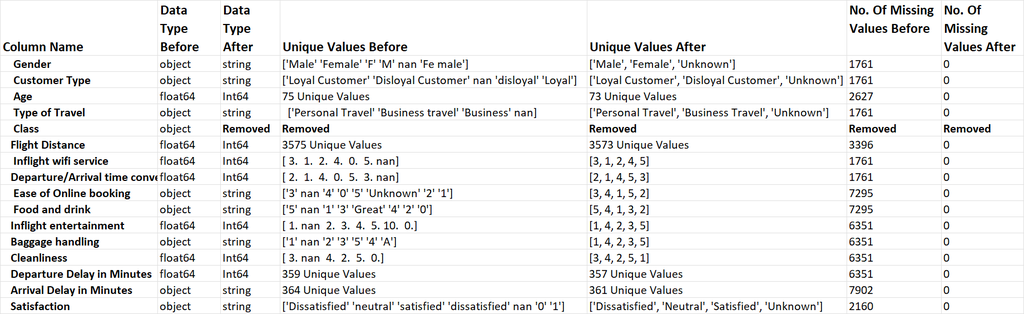